# Examples - R

```r
library(tidyverse)
library(ComplexUpset)
library(patchwork)
library(knitr)
library(scales)
```

# Prepare the datasets

```r
movies <- as.data.frame(ggplot2movies::movies)
movies %>%
  head(3) %>%
  kable()
```

| title | year | length | budget | rating | votes | r1 | r2 | r3 | r4 | r5 | r6 | r7 | r8 | r9 | r10 | mpaa | Action | Animation | Comedy | Drama | Documentary | Romance | Short |
| --- | --- | --- | --- | --- | --- | --- | --- | --- | --- | --- | --- | --- | --- | --- | --- | --- | --- | --- | --- | --- | --- | --- | --- |
| $ | 1971 | 121 | NA | 6.4 | 348 | 4.5 | 4.5 | 4.5 | 4.5 | 14.5 | 24.5 | 24.5 | 14.5 | 4.5 | 4.5 |  | 0 | 0 | 1 | 1 | 0 | 0 | 0 |
| $1000 a Touchdown | 1939 | 71 | NA | 6.0 | 20 | 0.0 | 14.5 | 4.5 | 24.5 | 14.5 | 14.5 | 14.5 | 4.5 | 4.5 | 14.5 |  | 0 | 0 | 1 | 0 | 0 | 0 | 0 |
| $21 a Day Once a Month | 1941 | 7 | NA | 8.2 | 5 | 0.0 | 0.0 | 0.0 | 0.0 | 0.0 | 24.5 | 0.0 | 44.5 | 24.5 | 24.5 |  | 0 | 1 | 0 | 0 | 0 | 0 | 1 |

```r
genres <- colnames(movies)[18:24]
genres
```

```
[1] "Action"      "Animation"   "Comedy"      "Drama"       "Documentary"
[6] "Romance"     "Short"
```

Convert the genre indicator columns to use boolean values:

```r
movies[genres] <- movies[genres] == 1
t(head(movies[genres], 3))
```

```
                1     2     3
Action      FALSE FALSE FALSE
Animation   FALSE FALSE  TRUE
Comedy       TRUE  TRUE FALSE
Drama        TRUE FALSE FALSE
Documentary FALSE FALSE FALSE
Romance     FALSE FALSE FALSE
Short       FALSE FALSE  TRUE
```

To keep the examples fast to compile we will operate on a subset of the movies with complete data:

```r
movies[movies$mpaa == '', 'mpaa'] = NA
movies = na.omit(movies)
```

Utility for changing output parameters in Jupyter notebooks (IRKernel kernel), not relevant if using RStudio or scripting R from terminal:

```
set_size = function(w, h, factor=1.5) {
    s = 1 * factor
    options(
        repr.plot.width=w * s,
        repr.plot.height=h * s,
        repr.plot.res=100 / factor,
        jupyter.plot_mimetypes='image/png',
        jupyter.plot_scale=1
    )
}
```

## 0. Basic usage

There are two required arguments:

- the first argument is expected to be a dataframe with both group indicator variables and covariates,
- the second argument specifies a list with names of column which indicate the group membership.

Additional arguments can be provided, such as `name` (specifies `xlab()` for intersection matrix) or `width_ratio` (specifies how much space should be occupied by the set size panel). Other such arguments are discussed at length later in this document.

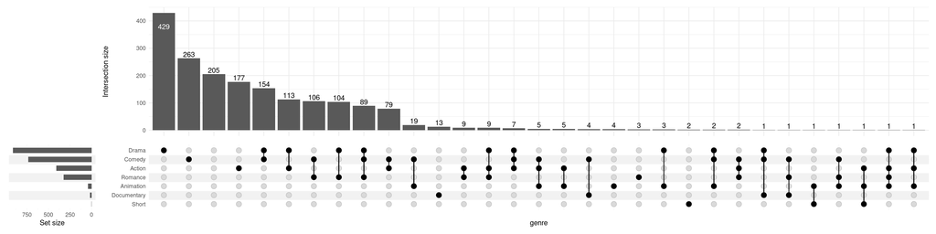

Figure 1

```r
# set_size(8, 3)
upset(movies, genres, name='genre', width_ratio=0.1)
```

### 0.1 Selecting intersections

We will focus on the intersections with at least ten members `(min_size=10)` and on a few variables which are significantly different between the intersections (see 2. Running statistical tests).

When using `min_size`, the empty groups will be skipped by default (e.g. *Short* movies would have no overlap with size of 10). To keep all groups pass `keep_empty_groups=TRUE`:

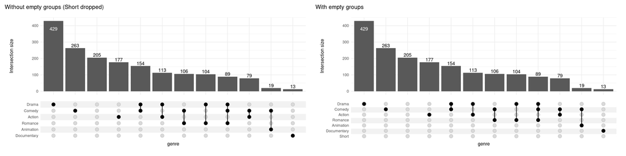

Figure 2

```r
(
  upset(movies, genres, name='genre', width_ratio=0.1, min_size=10, wrap=TRUE, set_sizes=FALSE) + ggtitle('Without empty groups (Short dropped)') +
  # adding plots is possible thanks to patchwork
  upset(movies, genres, name='genre', width_ratio=0.1, min_size=10, keep_empty_groups=TRUE, wrap=TRUE, set_sizes=FALSE) + ggtitle('With empty groups')
)
```

When empty columns are detected a warning will be issued. The silence it, pass `warn_when_dropping_groups=FALSE`. Complimentary `max_size` can be used in tandem. You can also select intersections by degree (`min_degree` and `max_degree`):

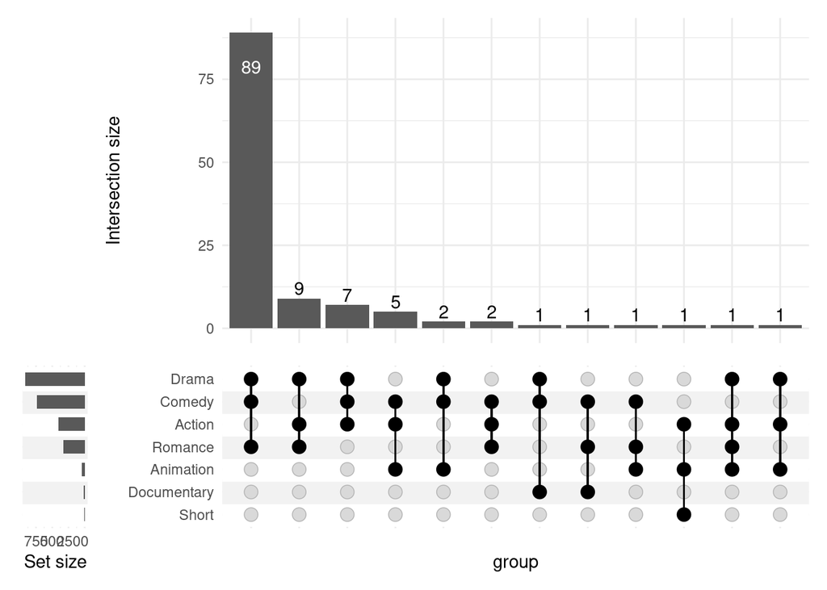

Figure 3

```r
upset(
  movies, genres, width_ratio=0.1,
  min_degree=3
)
```

Or request a constant number of intersections with `n_intersections`:

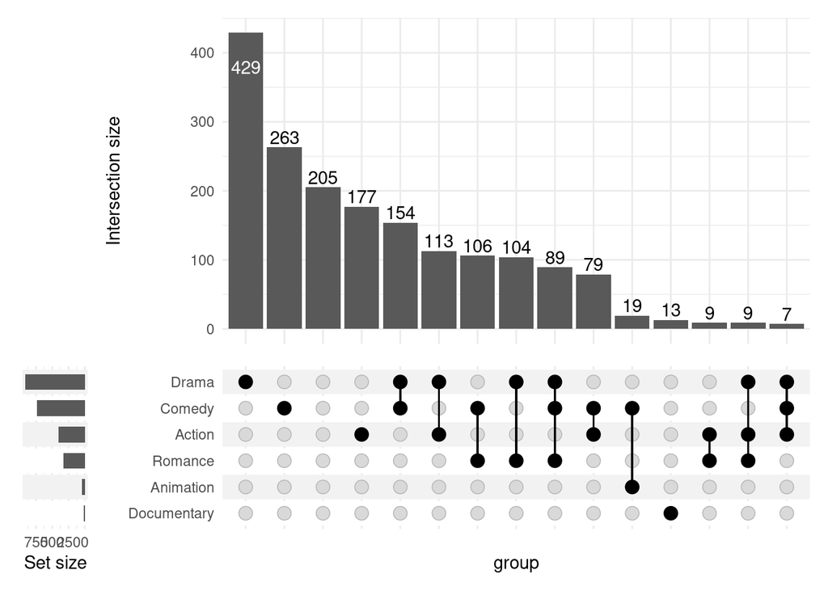

Figure 4

```r
upset(
  movies, genres, width_ratio=0.1,
  n_intersections=15
)
```

### 0.2 Region selection modes

There are four modes defining the regions of interest on corresponding Venn diagram:

- `exclusive_intersection` region: intersection elements that belong to the sets defining the intersection but not to any other set (alias: *distinct*), **default**
- `inclusive_intersection` region: intersection elements that belong to the sets defining the intersection including overlaps with other sets (alias: *intersect*)
- `exclusive_union` region: union elements that belong to the sets defining the union, *excluding* those overlapping with any other set
- `inclusive_union` region: union elements that belong to the sets defining the union, *including* those overlapping with any other set (alias: *union*) Example: given three sets $A$, $B$ and $C$ with number of elements defined by the Venn diagram below

```r
abc_data <- create_upset_abc_example()
head(abc_data) %>%
  kable()
```

| A | B | C |
| --- | --- | --- |
| TRUE | FALSE | FALSE |
| TRUE | FALSE | FALSE |
| TRUE | FALSE | FALSE |
| TRUE | FALSE | FALSE |
| TRUE | FALSE | FALSE |
| TRUE | FALSE | FALSE |

Figure 5

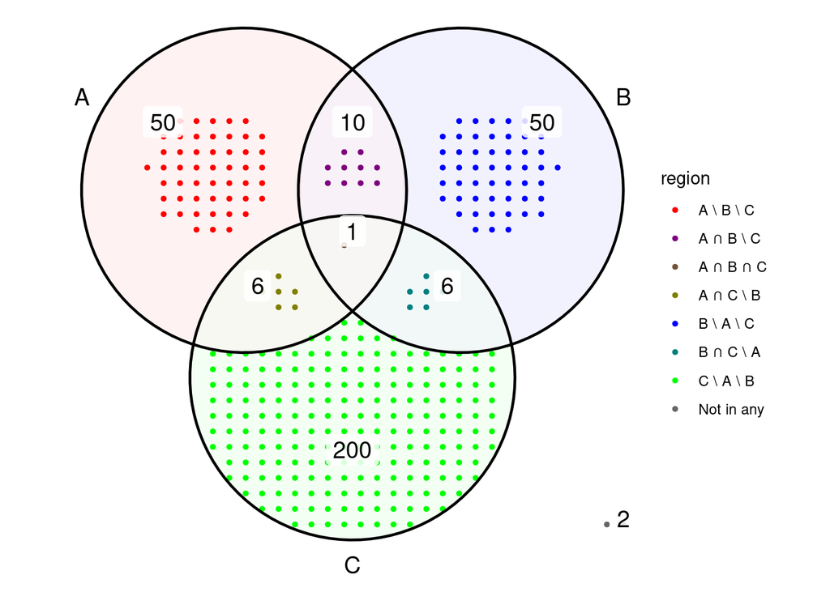

Figure 6

```r
abc_venn <- (
  ggplot(arrange_venn(abc_data)) +
    coord_fixed() +
    theme_void() +
    scale_color_venn_mix(abc_data)
  )
(abc_venn +
    geom_venn_region(data=abc_data, alpha=0.05) +
    geom_point(aes(x=x, y=y, color=region), size=1) +
    geom_venn_circle(abc_data) +
    geom_venn_label_set(abc_data, aes(label=region)) +
    geom_venn_label_region(
      abc_data, aes(label=size),
      outwards_adjust=1.75,
      position=position_nudge(y=0.2)
      ) +
    scale_fill_venn_mix(abc_data, guide='none')
  )
```

For the above sets $A$ and $B$ the region selection modes correspond to region of Venn diagram defined as follows:

- exclusive intersection: $(A \cap B) \setminus C$
- inclusive intersection: $A \cap B$
- exclusive union: $(A \cup B) \setminus C$
- inclusive union: $A \cup B$

and have the total number of elements as in the table below:

| members mode | exclusive int. | inclusive int. | exclusive union | inclusive union |
| --- | --- | --- | --- | --- |
| (A, B) | 10 | 11 | 110 | 123 |
| (A, C) == (B, C) | 6 | 7 | 256 | 273 |
| (A) == (B) | 50 | 67 | 50 | 67 |
| (C) | 200 | 213 | 200 | 213 |
| (A, B, C) | 1 | 1 | 323 | 323 |
| () | 2 | 2 | 2 | 2 |

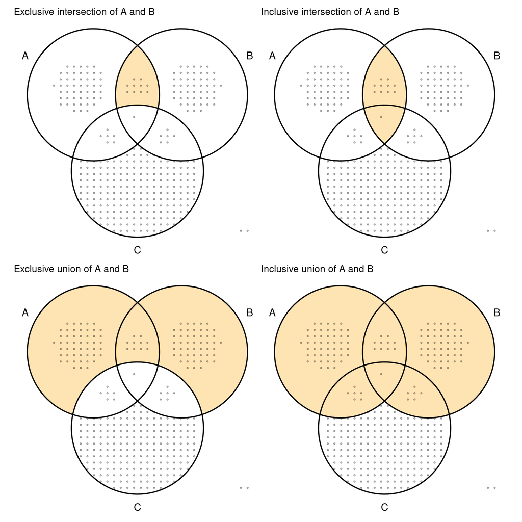

Figure 7

```r
simple_venn <- (
  abc_venn +
    geom_venn_region(data=abc_data, alpha=0.3) +
    geom_point(aes(x=x, y=y), size=0.75, alpha=0.3) +
    geom_venn_circle(abc_data) +
    geom_venn_label_set(abc_data, aes(label=region), outwards_adjust=2.55)
)

highlight <- function(regions) scale_fill_venn_mix(abc_data, guide='none', highlight=regions, inactive_color='NA')

(
  (
    simple_venn + highlight(c('A-B')) + labs(title='Exclusive intersection of A and B')
    | simple_venn + highlight(c('A-B', 'A-B-C')) + labs(title='Inclusive intersection of A and B')
  ) /
    (
      simple_venn + highlight(c('A-B', 'A', 'B')) + labs(title='Exclusive union of A and B')
      | simple_venn + highlight(c('A-B', 'A-B-C', 'A', 'B', 'A-C', 'B-C')) + labs(title='Inclusive union of A and B')
    )
)
```

When customizing the `intersection_size()` it is important to adjust the mode accordingly, as it defaults to `exclusive_intersection` and cannot be automatically deduced when user customizations are being applied:

```r
# sample dataset
head(abc_data) %>%
  kable()
```

| A | B | C |
| --- | --- | --- |
| TRUE | FALSE | FALSE |
| TRUE | FALSE | FALSE |
| TRUE | FALSE | FALSE |
| TRUE | FALSE | FALSE |
| TRUE | FALSE | FALSE |
| TRUE | FALSE | FALSE |

Figure 8

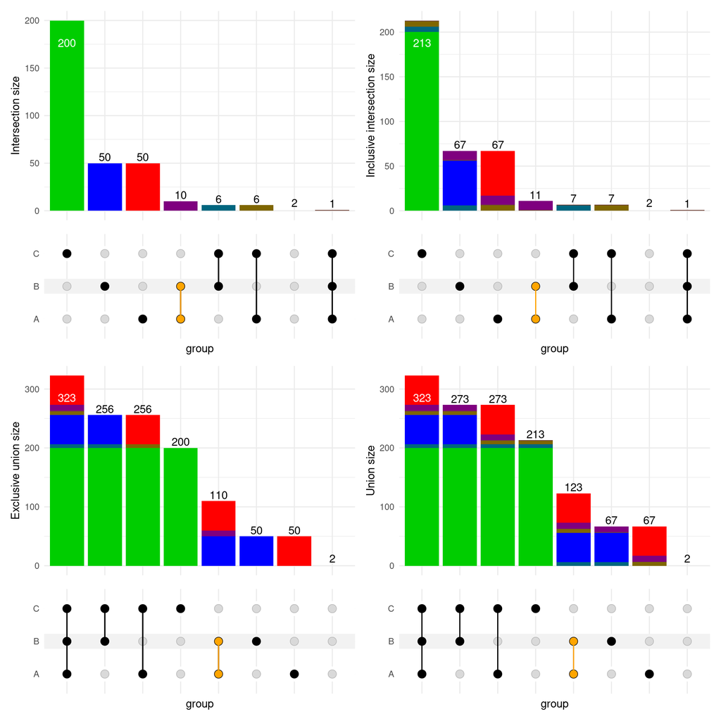

Figure 9

```r
abc_upset <- function(mode) upset(
  abc_data, c('A', 'B', 'C'), mode=mode, set_sizes=FALSE,
  encode_sets=FALSE,
  queries=list(upset_query(intersect=c('A', 'B'), color='orange')),
  base_annotations=list(
    'Size'=(
      intersection_size(
        mode=mode,
        mapping=aes(fill=exclusive_intersection),
        size=0,
        text=list(check_overlap=TRUE)
      ) + scale_fill_venn_mix(
        data=abc_data,
        guide='none',
        colors=c('A'='red', 'B'='blue', 'C'='green3')
      )
    )
  )
)

(
  (abc_upset('exclusive_intersection') | abc_upset('inclusive_intersection'))
  /
    (abc_upset('exclusive_union') | abc_upset('inclusive_union'))
)
```

### 0.3 Displaying all intersections

To display all possible intersections (rather than only the observed ones) use `intersections='all'`.

**Note 1**: it is usually desired to filter all the possible intersections down with `max_degree` and/or `min_degree` to avoid generating all combinations as those can easily use up all available RAM memory when dealing with multiple sets (e.g. all human genes) due to sheer number of possible combinations

**Note 2**: using `intersections='all'` is only reasonable for mode different from the default *exclusive intersection*.

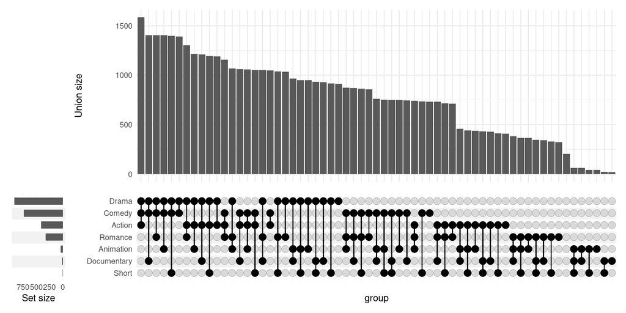

Figure 10

```r
upset(
  movies, genres,
  width_ratio=0.1,
  min_size=10,
  mode='inclusive_union',
  base_annotations=list('Size'=(intersection_size(counts=FALSE, mode='inclusive_union'))),
  intersections='all',
  max_degree=3
)
```

## 1. Adding components

We can add multiple annotation components (also called panels) using one of the three methods demonstrated below:

```r
# several metadata are present in the dataframe
head(movies) %>%
  kable()
```

|  | title | year | length | budget | rating | votes | r1 | r2 | r3 | r4 | r5 | r6 | r7 | r8 | r9 | r10 | mpaa | Action | Animation | Comedy | Drama | Documentary | Romance | Short |
| --- | --- | --- | --- | --- | --- | --- | --- | --- | --- | --- | --- | --- | --- | --- | --- | --- | --- | --- | --- | --- | --- | --- | --- | --- |
| 48 | ’Til There Was You | 1997 | 113 | 2.3e+07 | 4.8 | 799 | 4.5 | 4.5 | 4.5 | 14.5 | 14.5 | 14.5 | 14.5 | 4.5 | 4.5 | 14.5 | PG-13 | FALSE | FALSE | TRUE | FALSE | FALSE | TRUE | FALSE |
| 112 | 10 Things I Hate About You | 1999 | 97 | 1.6e+07 | 6.7 | 19095 | 4.5 | 4.5 | 4.5 | 4.5 | 4.5 | 14.5 | 24.5 | 14.5 | 14.5 | 14.5 | PG-13 | FALSE | FALSE | TRUE | FALSE | FALSE | TRUE | FALSE |
| 124 | 100 Mile Rule | 2002 | 98 | 1.1e+06 | 5.6 | 181 | 4.5 | 4.5 | 4.5 | 4.5 | 14.5 | 24.5 | 14.5 | 14.5 | 4.5 | 14.5 | R | FALSE | FALSE | TRUE | FALSE | FALSE | FALSE | FALSE |
| 173 | 13 Going On 30 | 2004 | 98 | 3.7e+07 | 6.4 | 7859 | 4.5 | 4.5 | 4.5 | 4.5 | 4.5 | 14.5 | 24.5 | 14.5 | 4.5 | 14.5 | PG-13 | FALSE | FALSE | TRUE | TRUE | FALSE | TRUE | FALSE |
| 186 | 13th Warrior, The | 1999 | 102 | 8.5e+07 | 6.1 | 14344 | 4.5 | 4.5 | 4.5 | 4.5 | 14.5 | 14.5 | 24.5 | 14.5 | 4.5 | 4.5 | R | TRUE | FALSE | FALSE | FALSE | FALSE | FALSE | FALSE |
| 197 | 15 Minutes | 2001 | 120 | 4.2e+07 | 6.1 | 10866 | 4.5 | 4.5 | 4.5 | 4.5 | 14.5 | 24.5 | 24.5 | 14.5 | 4.5 | 4.5 | R | FALSE | FALSE | FALSE | TRUE | FALSE | FALSE | FALSE |

Figure 11

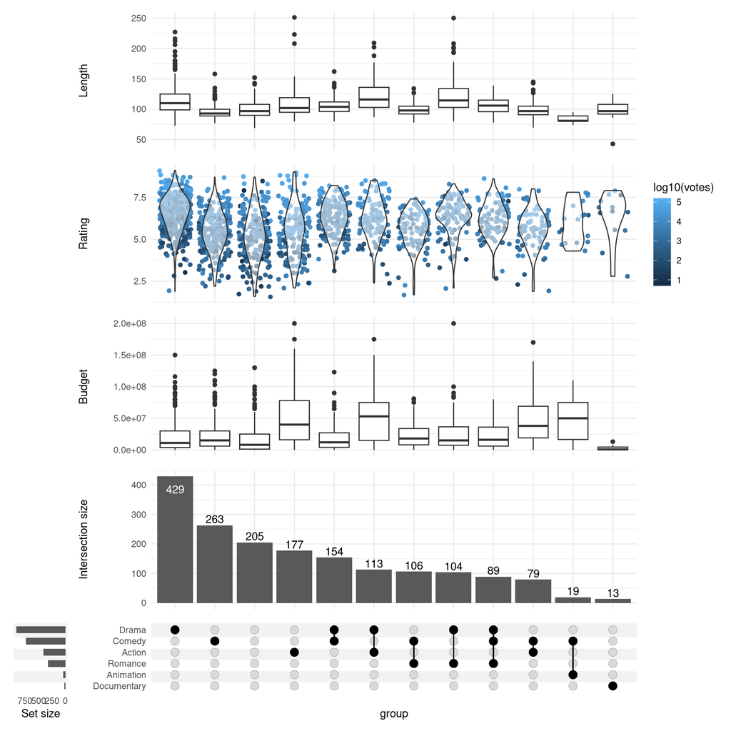

Figure 12

```r
set.seed(0)   # keep the same jitter for identical plots

upset(
  movies,
  genres,
  annotations = list(
    # 1st method - passing list:
    'Length'=list(
      aes=aes(x=intersection, y=length),
      # provide a list if you wish to add several geoms
      geom=geom_boxplot(na.rm=TRUE)
    ),
    # 2nd method - using ggplot
    'Rating'=(
      # note that aes(x=intersection) is supplied by default and can be skipped
      ggplot(mapping=aes(y=rating))
      # checkout ggbeeswarm::geom_quasirandom for better results!
      + geom_jitter(aes(color=log10(votes)), na.rm=TRUE)
      + geom_violin(alpha=0.5, na.rm=TRUE)
    ),
    # 3rd method - using `upset_annotate` shorthand
    'Budget'=upset_annotate('budget', geom_boxplot(na.rm=TRUE))
  ),
  min_size=10,
  width_ratio=0.1
)
```

You can also use barplots to demonstrate differences in proportions of categorical variables:

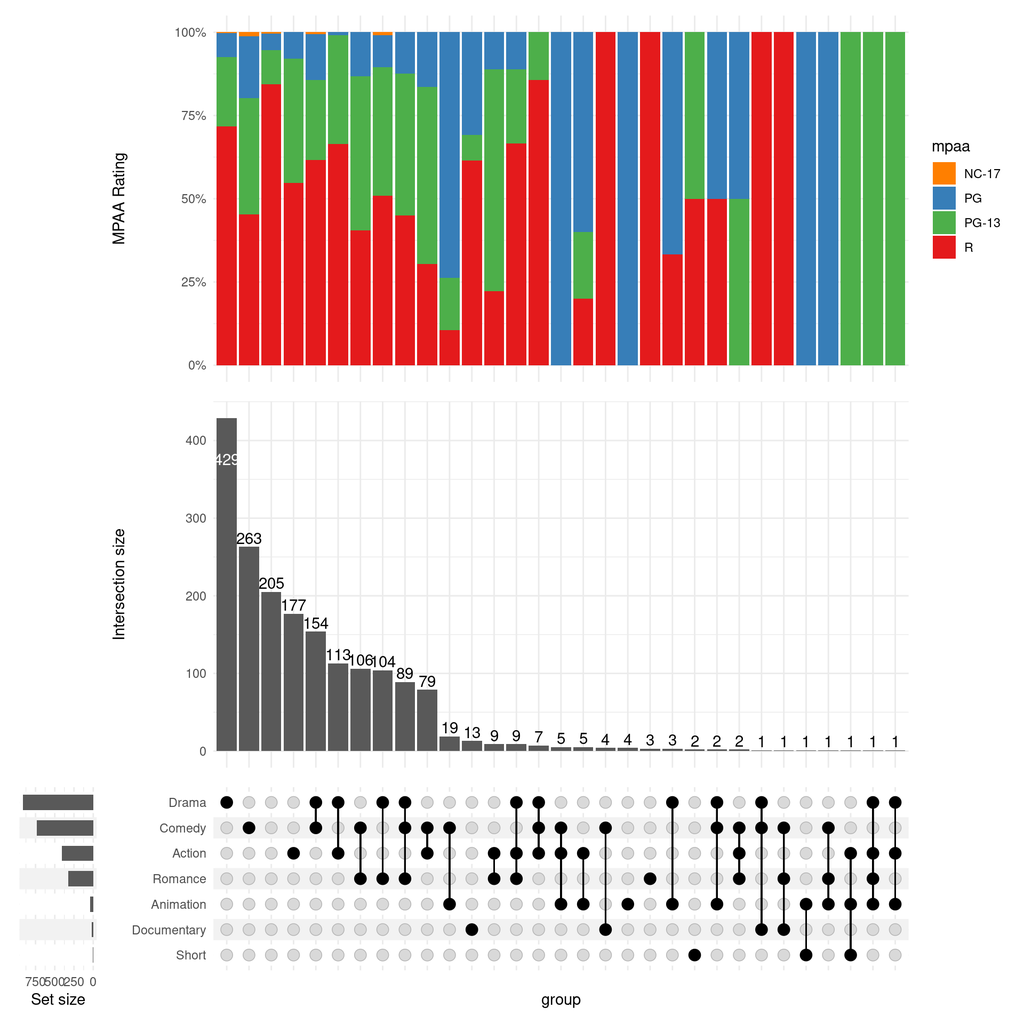

Figure 13

```r
upset(
  movies,
  genres,
  annotations = list(
    'MPAA Rating'=(
      ggplot(mapping=aes(fill=mpaa)) +
        geom_bar(stat='count', position='fill') +
        scale_y_continuous(labels=scales::percent_format()) +
        scale_fill_manual(values=c('R'='#E41A1C', 'PG'='#377EB8','PG-13'='#4DAF4A', 'NC-17'='#FF7F00')) +
        ylab('MPAA Rating')
    )
  ),
  width_ratio=0.1
)
```

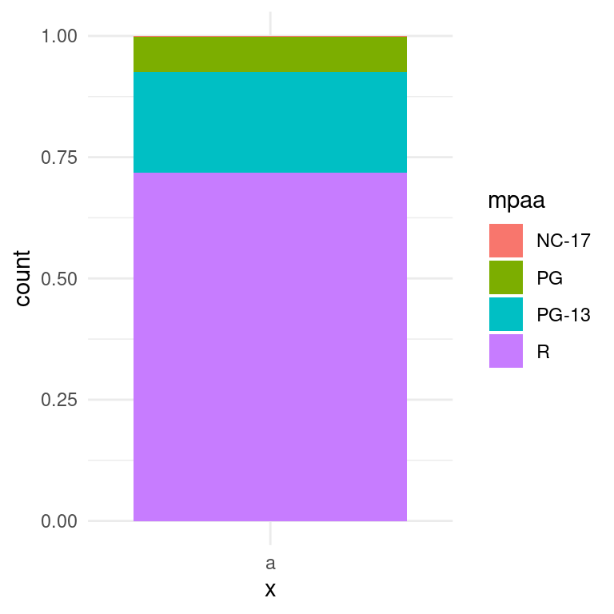

Figure 14

```r
# test the plot on a subset of the intersection
movies %>%
  filter(Drama == T,Action == F,Animation == F,Comedy ==F,Documentary==F,Romance==F,Short==F) %>%
  ggplot(aes(x="a",fill = mpaa)) + geom_bar(stat='count', position='fill') + theme_minimal()
```

### 1.1. Changing modes in annotations

Use `upset_mode` to change the mode of the annotation:

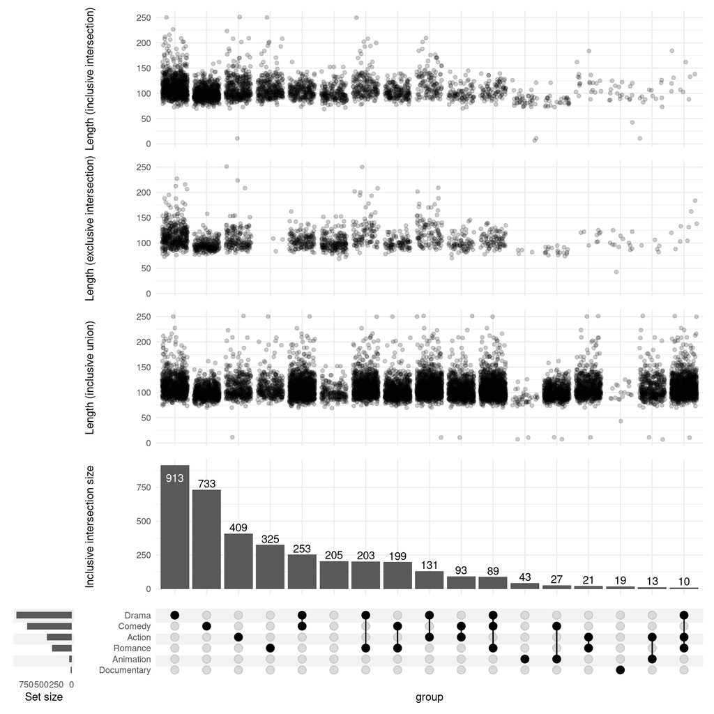

Figure 15

```r
set.seed(0)
upset(
  movies,
  genres,
  mode='inclusive_intersection',
  annotations = list(
    # if not specified, the mode will follow the mode set in `upset()` call (here: `inclusive_intersection`)
    'Length (inclusive intersection)'=(
      ggplot(mapping=aes(y=length))
      + geom_jitter(alpha=0.2, na.rm=TRUE)
    ),
    'Length (exclusive intersection)'=(
      ggplot(mapping=aes(y=length))
      + geom_jitter(alpha=0.2, na.rm=TRUE)
      + upset_mode('exclusive_intersection')
    ),
    'Length (inclusive union)'=(
      ggplot(mapping=aes(y=length))
      + geom_jitter(alpha=0.2, na.rm=TRUE)
      + upset_mode('inclusive_union')
    )
  ),
  min_size=10,
  width_ratio=0.1
)
```

## 2. Running statistical tests

```r
upset_test(movies, genres)
```

```
[1] "year, length, budget, rating, votes, r1, r2, r3, r4, r5, r6, r7, r8, r9, r10, mpaa differ significantly between intersections"
```

```
       variable      p.value statistic                         test
length   length 6.511525e-71 422.88444 Kruskal-Wallis rank sum test
rating   rating 1.209027e-46 301.72764 Kruskal-Wallis rank sum test
budget   budget 3.899860e-44 288.97476 Kruskal-Wallis rank sum test
r8           r8 9.900004e-39 261.28815 Kruskal-Wallis rank sum test
mpaa       mpaa 3.732200e-35 242.77939 Kruskal-Wallis rank sum test
r9           r9 1.433256e-30 218.78160 Kruskal-Wallis rank sum test
r1           r1 2.211600e-23 180.32740 Kruskal-Wallis rank sum test
r4           r4 1.008119e-18 154.62772 Kruskal-Wallis rank sum test
r3           r3 2.568227e-17 146.70217 Kruskal-Wallis rank sum test
r5           r5 9.823827e-16 137.66310 Kruskal-Wallis rank sum test
r7           r7 9.201549e-14 126.19243 Kruskal-Wallis rank sum test
r2           r2 2.159955e-13 124.00604 Kruskal-Wallis rank sum test
r10         r10 1.283470e-11 113.38113 Kruskal-Wallis rank sum test
votes     votes 2.209085e-10 105.79588 Kruskal-Wallis rank sum test
r6           r6 3.779129e-05  70.80971 Kruskal-Wallis rank sum test
year       year 2.745818e-02  46.55972 Kruskal-Wallis rank sum test
title     title 2.600003e-01  34.53375 Kruskal-Wallis rank sum test
                fdr
length 1.106959e-69
rating 1.027673e-45
budget 2.209921e-43
r8     4.207502e-38
mpaa   1.268948e-34
r9     4.060891e-30
r1     5.371029e-23
r4     2.142254e-18
r3     4.851095e-17
r5     1.670051e-15
r7     1.422058e-13
r2     3.059936e-13
r10    1.678384e-11
votes  2.682460e-10
r6     4.283013e-05
year   2.917431e-02
title  2.600003e-01
```

`Kruskal-Wallis rank sum test` is not always the best choice.

You can either change the test for:

- all the variables (`test=your.test`), or
- specific variables (using `tests=list(variable=some.test)` argument) The tests are called with `(formula=variable ~ intersection, data)` signature, such as accepted by `kruskal.test`. The result is expected to be a list with following members:
- `p.value`
- `statistic`
- `method`

It is easy to adapt tests which do not obey this signature/output convention; for example the Chi-squared test and anova can be wrapped with two-line functions as follows:

```r
chisq_from_formula = function(formula, data) {
  chisq.test(
    ftable(formula, data)
  )
}

anova_single = function(formula, data) {
  result = summary(aov(formula, data))
  list(
    p.value=result[[1]][['Pr(>F)']][[1]],
    method='Analysis of variance Pr(>F)',
    statistic=result[[1]][['F value']][[1]]
  )
}

custom_tests = list(
  mpaa=chisq_from_formula,
  budget=anova_single
)
```

```r
head(upset_test(movies, genres, tests=custom_tests))
```

```
[1] "year, length, budget, rating, votes, r1, r2, r3, r4, r5, r6, r7, r8, r9, r10, mpaa differ significantly between intersections"
```

```
       variable      p.value statistic                         test
length   length 6.511525e-71 422.88444 Kruskal-Wallis rank sum test
budget   budget 1.348209e-60  13.66395  Analysis of variance Pr(>F)
rating   rating 1.209027e-46 301.72764 Kruskal-Wallis rank sum test
mpaa       mpaa 9.799097e-42 406.33814   Pearson's Chi-squared test
r8           r8 9.900004e-39 261.28815 Kruskal-Wallis rank sum test
r9           r9 1.433256e-30 218.78160 Kruskal-Wallis rank sum test
                fdr
length 1.106959e-69
budget 1.145977e-59
rating 6.851151e-46
mpaa   4.164616e-41
r8     3.366002e-38
r9     4.060891e-30
```

Many tests will require at least two observations in each group. You can skip intersections with less than two members with `min_size=2`.

```r
bartlett_results = suppressWarnings(upset_test(movies, genres, test=bartlett.test, min_size=2))
```

```
[1] "NA, year, length, budget, rating, votes, r1, r2, r3, r4, r5, r6, r7, r8, r9, r10, NA differ significantly between intersections"
```

```r
tail(bartlett_results)
```

```
       variable      p.value statistic
year       year 1.041955e-67 386.53699
length   length 3.982729e-67 383.70148
budget   budget 7.637563e-50 298.89911
rating   rating 3.980194e-06  66.63277
title     title           NA        NA
mpaa       mpaa           NA        NA
                                            test          fdr
year   Bartlett test of homogeneity of variances 1.302444e-67
length Bartlett test of homogeneity of variances 4.595457e-67
budget Bartlett test of homogeneity of variances 8.183103e-50
rating Bartlett test of homogeneity of variances 3.980194e-06
title  Bartlett test of homogeneity of variances           NA
mpaa   Bartlett test of homogeneity of variances           NA
```

### 2.1 Ignore specific variables

You may want to exclude variables which are:

- highly correlated and therefore interfering with the FDR calculation, or
- simply irrelevant

In the movies example, the title variable is not a reasonable thing to compare. We can ignore it using:

```r
# note: title no longer present
rownames(upset_test(movies, genres, ignore=c('title')))
```

```
[1] "year, length, budget, rating, votes, r1, r2, r3, r4, r5, r6, r7, r8, r9, r10, mpaa differ significantly between intersections"
```

```
 [1] "length" "rating" "budget" "r8"     "mpaa"   "r9"     "r1"     "r4"
 [9] "r3"     "r5"     "r7"     "r2"     "r10"    "votes"  "r6"     "year"
```

## 3. Adjusting “Intersection size”

### 3.1 Counts

The counts over the bars can be disabled:

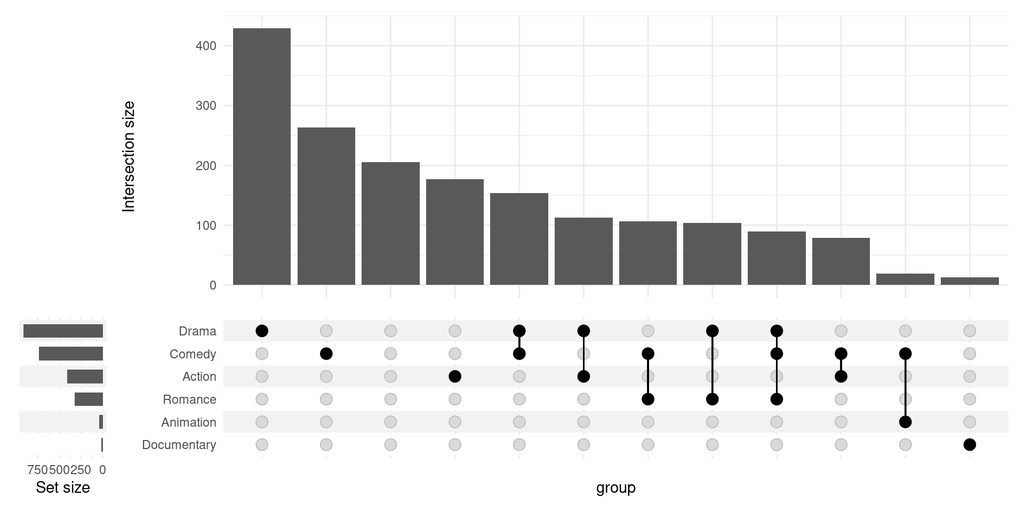

Figure 16

```r
upset(
  movies,
  genres,
  base_annotations=list(
    'Intersection size'=intersection_size(counts=FALSE)
  ),
  min_size=10,
  width_ratio=0.1
)
```

The colors can be changed, and additional annotations added:

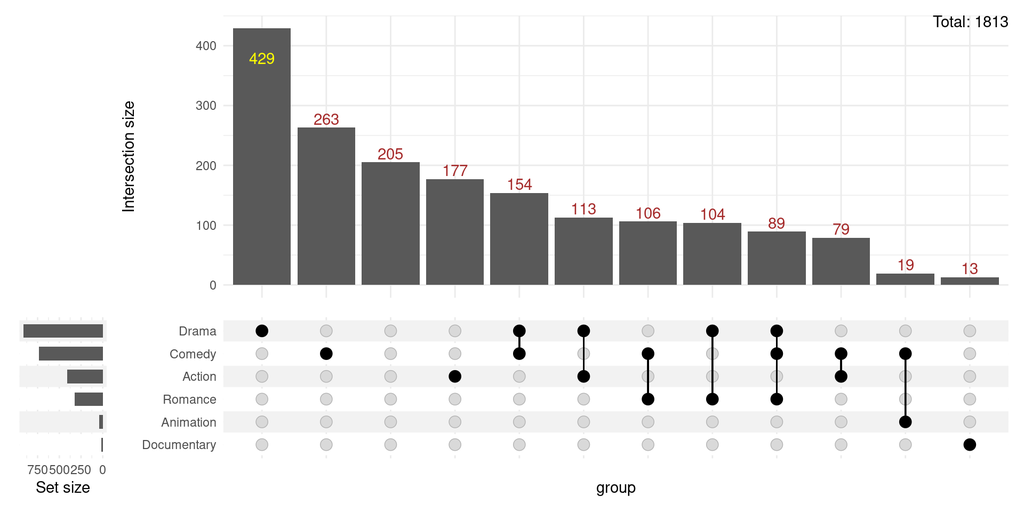

Figure 17

```r
upset(
  movies,
  genres,
  base_annotations=list(
    'Intersection size'=intersection_size(
      text_colors=c(
        on_background='brown', on_bar='yellow'
      )
    ) +
      annotate(
        geom='text', x=Inf, y=Inf,
        label=paste('Total:', nrow(movies)),
        vjust=1, hjust=1
        ) +
      ylab('Intersection size')
    ),
  min_size=10,
  width_ratio=0.1
)
```

Any parameter supported by `geom_text` can be passed in `text` list:

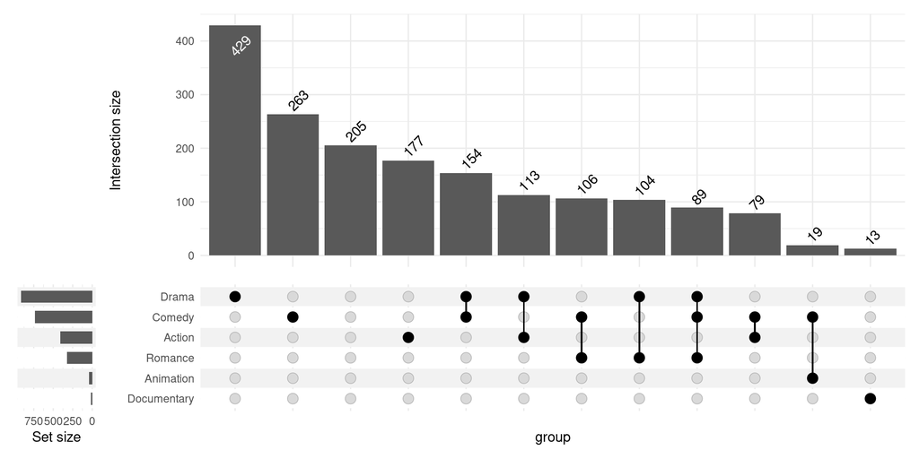

Figure 18

```r
upset(
  movies,
  genres,
  base_annotations=list(
    'Intersection size'=intersection_size(
      text=list(
        vjust=-0.1,
        hjust=-0.1,
        angle=45
      )
    )
  ),
  min_size=10,
  width_ratio=0.1
)
```

### 3.2 Fill the bars

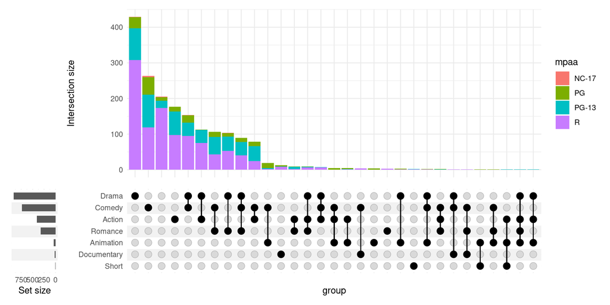

Figure 19

```r
upset(
  movies,
  genres,
  base_annotations=list(
    'Intersection size'=intersection_size(
      counts=FALSE,
      mapping=aes(fill=mpaa)
    )
  ),
  width_ratio=0.1
)
```

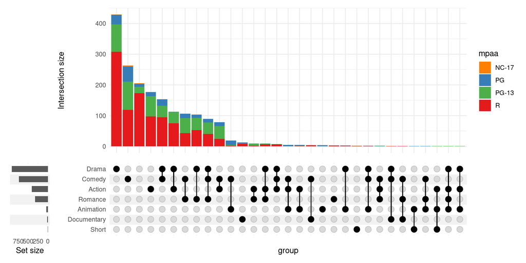

Figure 20

```r
upset(
  movies,
  genres,
  base_annotations=list(
    'Intersection size'=intersection_size(
      counts=FALSE,
      mapping=aes(fill=mpaa)
    ) + scale_fill_manual(values=c(
      'R'='#E41A1C', 'PG'='#377EB8',
      'PG-13'='#4DAF4A', 'NC-17'='#FF7F00'
    ))
  ),
  width_ratio=0.1
)
```

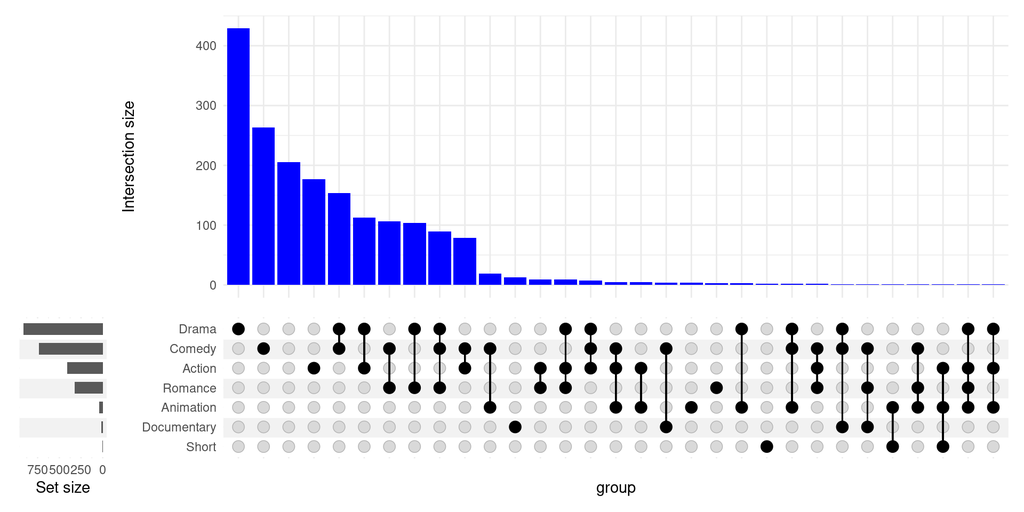

Figure 21

```r
upset(
  movies,
  genres,
  base_annotations=list(
    'Intersection size'=intersection_size(
      counts=FALSE,
      mapping=aes(fill='bars_color')
    ) + scale_fill_manual(values=c('bars_color'='blue'), guide='none')
  ),
  width_ratio=0.1
)
```

### 3.3 Adjusting the height ratio

Setting `height_ratio=1` will cause the intersection matrix and the intersection size to have an equal height:

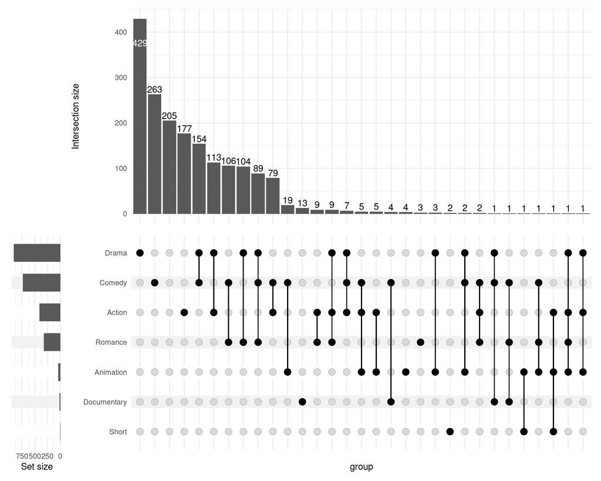

Figure 22

```r
upset(
  movies,
  genres,
  height_ratio=1,
  width_ratio=0.1
)
```

### 3.5 Hiding intersection size

You can always disable the intersection size altogether:

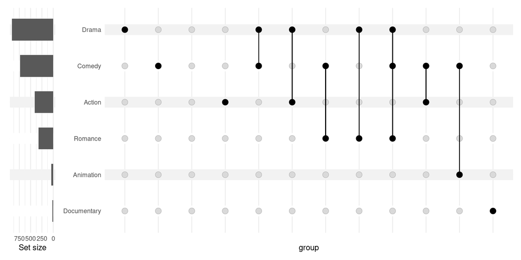

Figure 23

```r
upset(
  movies,
  genres,
  base_annotations=list(),
  min_size=10,
  width_ratio=0.1
)
```

### 3.6 Showing intersection size/union size ratio

It can be useful to visualise which intersections are larger than expected by chance (assuming equal probability of belonging to multiple sets); this can be achieved using the intersection size/union size ratio.

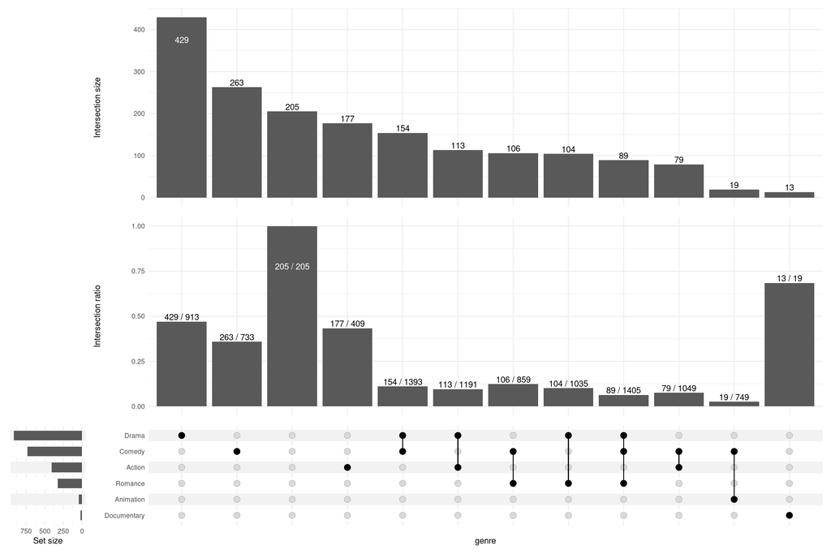

Figure 24

```r
upset(
  movies, genres, name='genre', width_ratio=0.1, min_size=10,
  base_annotations=list(
    'Intersection size'=intersection_size(),
    'Intersection ratio'=intersection_ratio()
  )
)
```

The plot above tells us that the analysed documentary movies are almost always (in over 60% of cases) documentaries (and nothing more!), while comedies more often include elements of other genres (e.g. drama, romance) rather than being comedies alone (like stand-up shows). Understand the documentary conclusions.

```r
# Pull all the documentaries (union)
movies %>%
  filter(Documentary == T) %>%
  dim()
```

```
[1] 19 24
```

```r
test <- movies %>%
  filter(Documentary == T) %>%
  upset(.,genres)

# generate the plot. notice that the total of documentary is 19, while 13 is the number of stric documentaries
test

# how to pull the labelled intersections
# define a dataframe with movies titles repeated per category
df1 <- lapply(genres,function(x){
  movies %>%
    filter(Documentary == T) %>%
    filter(.data[[x]] == T) %>%
    mutate(cat = x) %>%
    select(title,cat)
}) %>%
  bind_rows()

# now pull the individula films title
df2 <- movies %>%
  filter(Documentary == T) %>%
  pull(title) %>%
  unique(.) %>%
  data.frame(title = .)

# now loop the process for each movie and save the category
df_int <- lapply(df2$title,function(x){

  # pull the name of the intersections
  intersection <- df1 %>%
    dplyr::filter(title == x) %>%
    arrange(cat) %>%
    pull("cat") %>%
    paste0(collapse = "|")

  # build the dataframe
  data.frame(gene = x,int = intersection)
}) %>%
  bind_rows() %>%
  arrange(int)

head(df_int) %>%
  kable()
```

| gene | int |
| --- | --- |
| DysFunktional Family | Comedy\|Documentary |
| Jackass: The Movie | Comedy\|Documentary |
| Martin Lawrence Live: Runteldat | Comedy\|Documentary |
| Original Kings of Comedy, The | Comedy\|Documentary |
| Bowling for Columbine | Comedy\|Documentary\|Drama |
| 20 Dates | Comedy\|Documentary\|Romance |

Figure 25

| int | n |
| --- | --- |
| Documentary | 13 |
| Comedy\|Documentary | 4 |
| Comedy\|Documentary\|Drama | 1 |
| Comedy\|Documentary\|Romance | 1 |

Figure 26

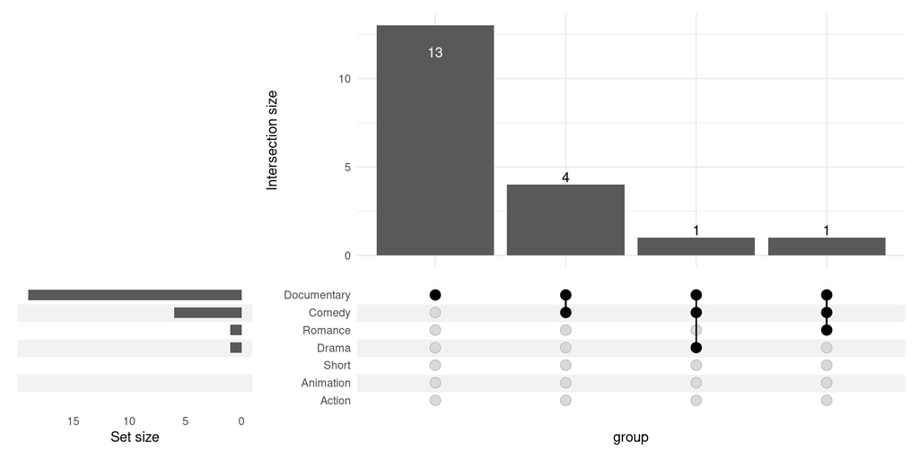

Figure 27

```r
# confirm the numbers
df_int %>%
  group_by(int) %>%
  summarise(n=n()) %>%
  arrange(desc(n)) %>%
  kable()
```

Understand the comedy conclusions.

```r
# Pull all the documentaries (union)
movies %>%
  filter(Comedy == T) %>%
  dim()
```

```
[1] 733  24
```

```r
test <- movies %>%
  filter(Comedy == T) %>%
  upset(.,genres)

# generate the plot. notice that the total of documentary is 19, while 13 is the number of stric documentaries
test

# how to pull the labelled intersections
# define a dataframe with movies titles repeated per category
df1 <- lapply(genres,function(x){
  movies %>%
    filter(Comedy == T) %>%
    filter(.data[[x]] == T) %>%
    mutate(cat = x) %>%
    select(title,cat)
}) %>%
  bind_rows()

# now pull the individula films title
df2 <- movies %>%
  filter(Comedy == T) %>%
  pull(title) %>%
  unique(.) %>%
  data.frame(title = .)

# now loop the process for each movie and save the category
df_int <- lapply(df2$title,function(x){

  # pull the name of the intersections
  intersection <- df1 %>%
    dplyr::filter(title == x) %>%
    arrange(cat) %>%
    pull("cat") %>%
    paste0(collapse = "|")

  # build the dataframe
  data.frame(gene = x,int = intersection)
}) %>%
  bind_rows() %>%
  arrange(int)

head(df_int) %>%
  kable()
```

| gene | int |
| --- | --- |
| Incredibles, The | Action\|Animation\|Comedy |
| Looney Tunes: Back in Action | Action\|Animation\|Comedy |
| Powerpuff Girls, The | Action\|Animation\|Comedy |
| Road to El Dorado, The | Action\|Animation\|Comedy |
| Shark Tale | Action\|Animation\|Comedy |
| 3000 Miles to Graceland | Action\|Comedy |

Figure 28

| int | n |
| --- | --- |
| Comedy | 263 |
| Comedy\|Drama | 154 |
| Comedy\|Romance | 106 |
| Comedy\|Drama\|Romance | 89 |
| Action\|Comedy | 79 |
| Animation\|Comedy | 19 |
| Action\|Comedy\|Drama | 7 |
| Action\|Animation\|Comedy | 5 |
| Comedy\|Documentary | 4 |
| Action\|Comedy\|Romance | 2 |
| Animation\|Comedy\|Drama | 2 |
| Animation\|Comedy\|Romance | 1 |
| Comedy\|Documentary\|Drama | 1 |
| Comedy\|Documentary\|Romance | 1 |

Figure 29

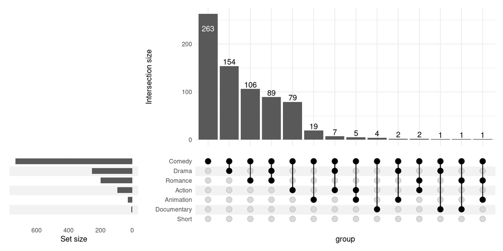

Figure 30

```r
# confirm the numbers
df_int %>%
  group_by(int) %>%
  summarise(n=n()) %>%
  arrange(desc(n)) %>%
  kable()
```

### 3.7 Showing percentages

`text_mapping` can be used to manipulate the aesthetics of the labels. Using the `intersection_size` and `union_size` one can calculate percentage of items in the intersection (relative to the potential size of the intersection). A `upset_text_percentage(digits=0, sep='')` shorthand is provided for convenience:

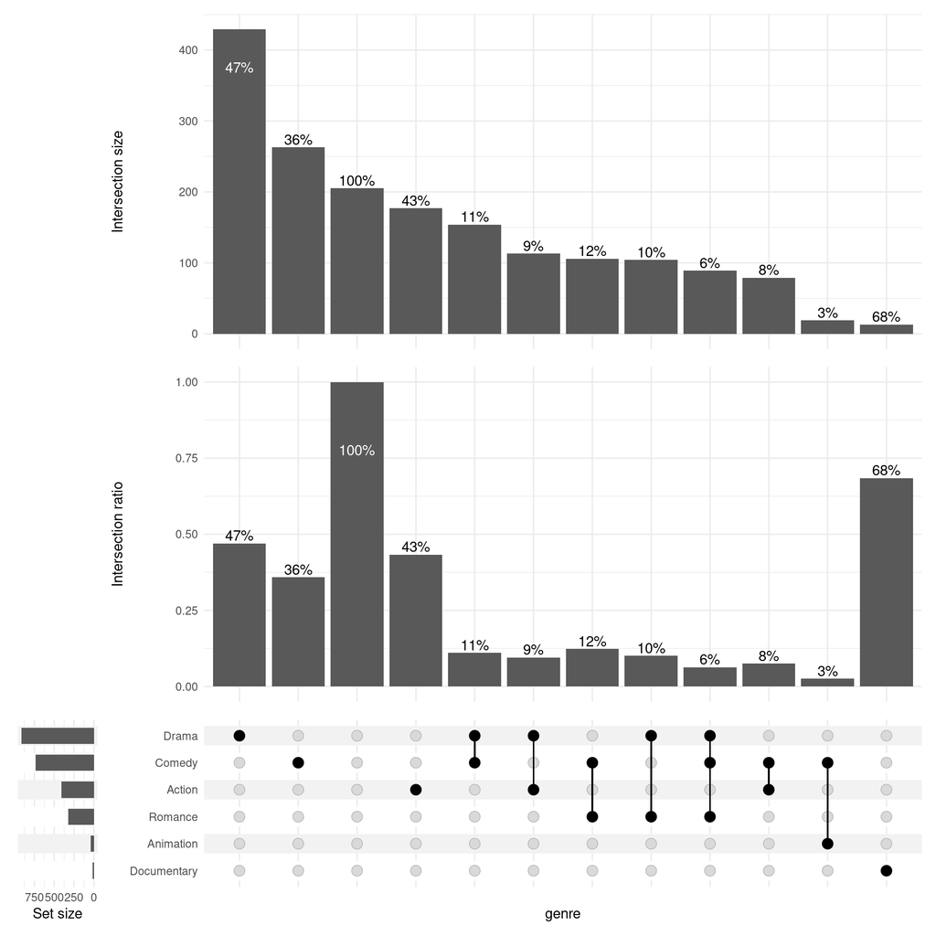

Figure 31

```r
upset(
  movies, genres, name='genre', width_ratio=0.1, min_size=10,
  base_annotations=list(
    # with manual aes specification:
    'Intersection size'=intersection_size(text_mapping=aes(label=paste0(round(
      !!get_size_mode('exclusive_intersection')/!!get_size_mode('inclusive_union') * 100
    ), '%'))),
    # using shorthand:
    'Intersection ratio'=intersection_ratio(text_mapping=aes(label=!!upset_text_percentage()))
  )
)
```

Also see 10. Display percentages. #### 3.7.1 Showing percentages and numbers together

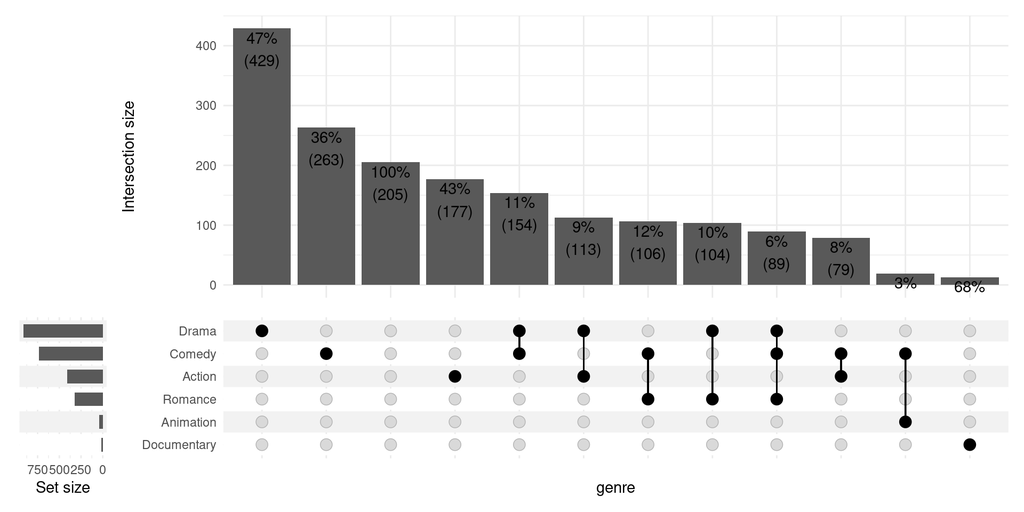

Figure 32

```r
upset(
    movies, genres, name='genre', width_ratio=0.1, min_size=10,
    base_annotations=list(
      'Intersection size'=intersection_size(
        text_mapping=aes(label=paste0(
          !!upset_text_percentage(),
          '\n',
          '(',
          !!get_size_mode('exclusive_intersection'),
          ')'
        )),
        bar_number_threshold=1,
        text=list(vjust=1.1)
      )
    )
  )
```

#### 3.8 Custom positioning on bars/background

If adjusting `bar_number_threshold` is not sufficient, you can specify custom rules for placement of text on bars/background:

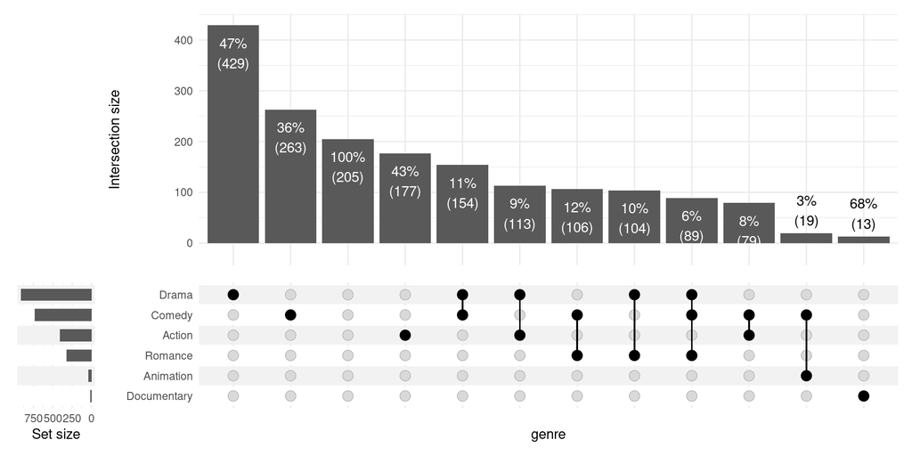

Figure 33

```r
size <- get_size_mode('exclusive_intersection')
upset(
    movies, genres, name='genre', width_ratio=0.1, min_size=10,
    base_annotations=list(
      'Intersection size'=intersection_size(
        text_mapping=aes(
          label=paste0(
            !!upset_text_percentage(),
            '\n(', !!size, ')'
          ),
          colour=ifelse(!!size > 50, 'on_bar', 'on_background'),
          y=ifelse(!!size > 50, !!size - 100, !!size)
        )
      )
    )
  )
```

### 3.8 Further adjustments using ggplot2 functions

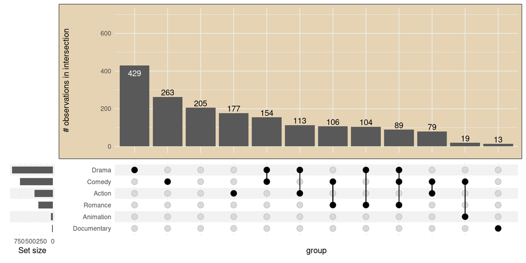

Figure 34

```r
upset(
    movies, genres, width_ratio=0.1,
    base_annotations = list(
      'Intersection size'=(
        intersection_size()
        + ylim(c(0, 700))
        + theme(plot.background=element_rect(fill='#E5D3B3'))
        + ylab('# observations in intersection')
      )
    ),
    min_size=10
  )
```

## 4. Adjusting “set size”

When using thresholding or selection criteria (such as `min_size` or `n_intersections`) the change in number of elements in each set size is not reflected in the set sizes plot by default. You can change this by providing `filter_intersections=TRUE` to `upset_set_size`.

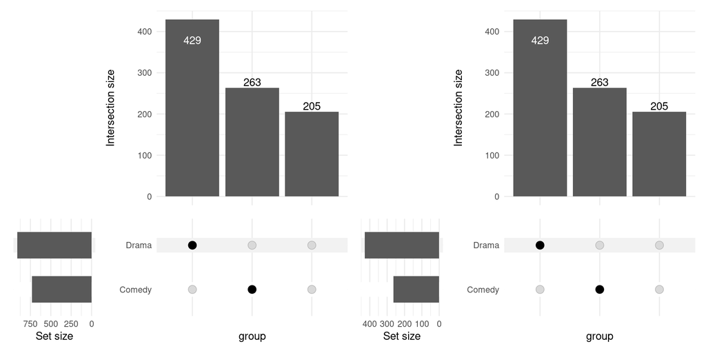

Figure 35

```r
upset(
    movies, genres,
    min_size=200,
    set_sizes=upset_set_size()
  ) | upset(
    movies, genres,
    min_size=200,
    set_sizes=upset_set_size(filter_intersections=TRUE)
  )
```

### 4.1 Rotate labels

To rotate the labels modify corresponding theme:

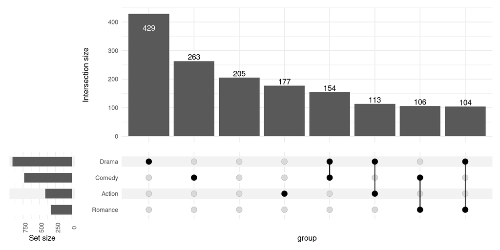

Figure 36

```r
upset(
    movies, genres,
    min_size=100,
    width_ratio=0.15,
    set_sizes=(
      upset_set_size()
      + theme(axis.text.x=element_text(angle=90))
    )
  )
```

To display the ticks:

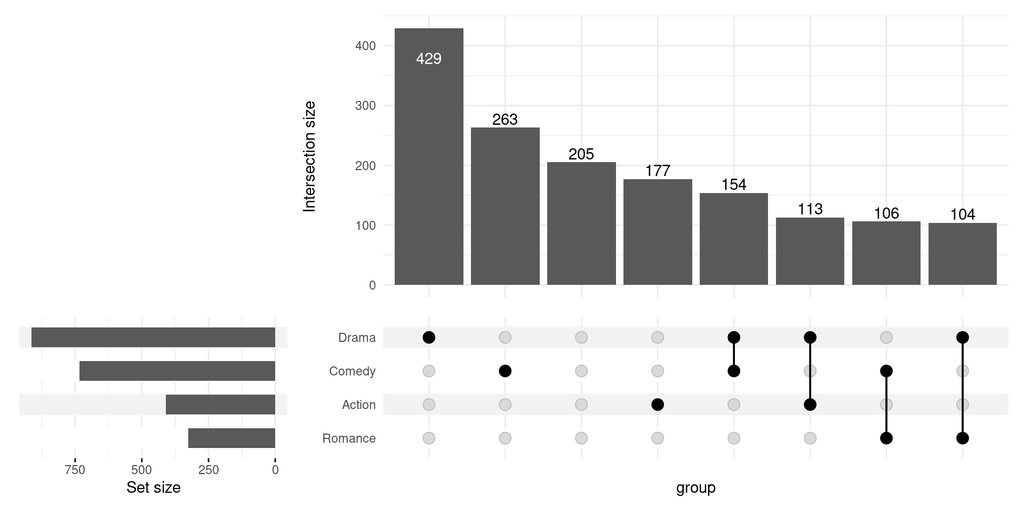

Figure 37

```r
upset(
    movies, genres, width_ratio=0.3, min_size=100,
    set_sizes=(
      upset_set_size()
      + theme(axis.ticks.x=element_line())
    )
  )
```

### 4.2 Modify geoms and other layers

Arguments of the `geom_bar` can be adjusted in `upset_set_size`; it can use a different geom, or be replaced with a custom list of layers altogether:

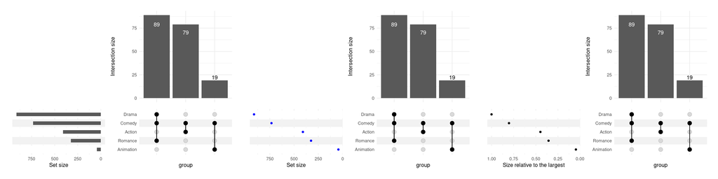

Figure 38

```r
  (
    upset(
      movies, genres, width_ratio=0.5, max_size=100, min_size=15, wrap=TRUE,
      set_sizes=upset_set_size(
        geom=geom_bar(width=0.4)
      )
    )
    +
      upset(
        movies, genres, width_ratio=0.5, max_size=100, min_size=15, wrap=TRUE,
        set_sizes=upset_set_size(
          geom=geom_point(
            stat='count',
            color='blue'
          )
        )
      )
    +
      upset(
        movies, genres, width_ratio=0.5, max_size=100, min_size=15, wrap=TRUE,
        set_sizes=(
          upset_set_size(
            geom=geom_point(stat='count'),
            mapping=aes(y=..count../max(..count..)),
          )
          + ylab('Size relative to the largest')
        )
      )
  )
```